# Transient Simulations Unsaturated Zone

G. Bier

April, 2025

# Introduction

Markdown to set up an unsaturated zone model and to analyze the impact of the van Genuchten parameters on Evapotranspiration, moisture distribution and groundwater recharge.

### Cleaning the memory and loading required package(s)

```
rm(list = ls())
library(FVFE1D)
library(MIPLOT)
```

### Loading the soil data (Staring Series)

```
load(file='Staring.Rdata')
print(paste("Soil type: ",names(soil.set)," ",lapply(soil.set, function(x) x$name)))
```

```
 [1] "Soil type:  B1   Non-loamy sand"
 [2] "Soil type:  B2   Loamy sand"
 [3] "Soil type:  B3   Very loamy sand"
 [4] "Soil type:  B4   Extremely loamy sand"
 [5] "Soil type:  B5   Coarse sand"
 [6] "Soil type:  B6   Boulder clay"
 [7] "Soil type:  B7   Sandy loam"
 [8] "Soil type:  B8   Silt loam"
 [9] "Soil type:  B9   Clayey loam"
[10] "Soil type:  B10   Light clay"
[11] "Soil type:  B11   Heavy clay"
[12] "Soil type:  B12   Very heavy clay"
[13] "Soil type:  B13   Loam"
[14] "Soil type:  B14   Heavy loam"
[15] "Soil type:  B15   Peaty sand"
```

[output cut: 21 more lines]

```
print(paste("Ksat values: ",lapply(soil.set, function(y) y$name),"  ",lapply(soil.set, function(x) x$ksat)))
```

```
 [1] "Ksat values:  Non-loamy sand    23.41"
 [2] "Ksat values:  Loamy sand    12.52"
 [3] "Ksat values:  Very loamy sand    15.42"
 [4] "Ksat values:  Extremely loamy sand    29.22"
 [5] "Ksat values:  Coarse sand    52.91"
 [6] "Ksat values:  Boulder clay    100.69"
 [7] "Ksat values:  Sandy loam    14.07"
 [8] "Ksat values:  Silt loam    2.36"
 [9] "Ksat values:  Clayey loam    1.54"
[10] "Ksat values:  Light clay    0.7"
[11] "Ksat values:  Heavy clay    4.53"
[12] "Ksat values:  Very heavy clay    5.37"
[13] "Ksat values:  Loam    12.98"
[14] "Ksat values:  Heavy loam    0.8"
[15] "Ksat values:  Peaty sand    81.28"
```

[output cut: 21 more lines]

# Model setup

## Internal flux in the unsaturated zone

The equation describing the internal flux in the unsaturated zone strongly resembles the basic Darcy equation to simulate flow in the saturated zone. Most important differences are the hydraulic conductivity and the state. Now the state is $\psi$ instead of $H$. Both are related: $H = \psi + z$ where the $z$ is the datum/reference (in the Netherlands: “NAP”).

$$q=-k(\psi)\left [\frac{\partial \psi}{\partial z} + 1 \right]$$

## Building the model for the Holterbeg

**Be aware** the length unit is in cm!

The model is based on:

- 1D vertical flow
- Richards/Darcy’s equation
- Top boundary flux based precipitation
- Bottom boundary flux based on Dirichlet or Cauchy type
- Spatial flux for the rooting function for transpiration
- Soil evaporation is neglected

## Choose a soil type from the Staring series

From the Staring Series you can choose a typical soil type for ice pushed ridges. For example the soil type “Coarse sand” B5.

```
soiltype = soil.set$B5

print(unlist(soiltype))
```

```
$soiltype
[1] "B5"

$theta.res
[1] 0.01

$theta.sat
[1] 0.36

$n
[1] 1.933

$alpha
[1] 0.0452

$ksat
[1] 52.91

$lambda
[1] -0.359

$name
[1] "Coarse sand"

$k.fun
function (v)
.approxfun(x, y, v, method, yleft, yright, f)
<environment: 0x00000145957321c8>

$theta.fun
function (v)
.approxfun(x, y, v, method, yleft, yright, f)
<environment: 0x00000145957325b8>

$c.fun
function (v)
.approxfun(x, y, v, method, yleft, yright, f)
<environment: 0x00000145957329a8>

$Richards.flux
function(x,state,gradstate)
                        {
                          return(-soil.set$B5$k.fun(state)*(gradstate+1))
                        }
```

```
## domain of the model
top = 0.0  # at the surface
bottom = -1000#-200 # so 200 cm below surface!!

log_top = 0.1
log_bottom = log10(-bottom)
log_z = seq(from = log_top, to = log_bottom,by = 0.01)
nodes = -10^log_z


domain=c(bottom,top)


###description of the internal flux##############
unsatdarcy.flux = function(z,psi,dpsidz)
{
  return(-soiltype$k.fun(psi)*(dpsidz+1))
}

################### make the model #################
UnsatStat = newFLOW1D(domain,unsatdarcy.flux,"Unsaturated zone, 1D stationary")

####### discretisation #####################
# position the nodes 2 cm apart
#nodes = seq(from=domain[1],to=domain[2],by=1)
set.discretisation(UnsatStat,nodes,"FV") #setting to FEquartic slows transient simulations way too much
# An initialisation is certainly important (as the default initialisation by zeros does not make sense here).
# So we initialize with a no-flux profile:
Psi.equi = approxfun(c(domain[1],domain[2]),c(domain[2],domain[1]))
do.initialize(UnsatStat,Psi.equi)

# We want to avoid pressures to be too negative (<-1E-5)
Psi.in.range = function(z,Psi) # it has 2 arguments; the position and the state. Set the min. value to pF4.2 not pF5
{
  if(Psi<=-1*10^4.2) return(FALSE)
   #if(Psi<=-1*10^5) return(FALSE)
  else return(TRUE)
}
set.isacceptable(UnsatStat,Psi.in.range) #the set.isacceptable function limits the possible values that the state can become

############## Boundary conditions ##################
set.BC.fixedstate(UnsatStat,"left",0.0)
# At the bottom of the model, where the groundwater level is located, both pressure head and elevation head are zero.

ppt = 0.1
set.BC.fixedflux(UnsatStat,"right","ppt")
# 0.1cm/d=1mm/d. Although this flow is directed downwards, we define it positive because it goes into the domain.


######## checking and solving the model ####################
summary(UnsatStat)
```

```
one dimensional flow model
name:  Unsaturated zone, 1D stationary
model has no spatial fluxes
model has no point fluxes
left BC is of type state
right BC is of type given flux

numerical model of type FV1D
number of nodes is  291
```

```
solve.steps(UnsatStat,verboselevel=1)
```

```
[1] "iteration 1 ; RMSM= 0.00586707626528898 ; MAM= 0.0999127084470765"
[1] "iteration 2 ; RMSM= 0.00585416993518117 ; MAM= 0.0996925994624694"
[1] "iteration 3 ; RMSM= 0.00579735444885904 ; MAM= 0.0987203328809302"
[1] "iteration 4 ; RMSM= 0.00556517470029531 ; MAM= 0.0947054666039285"
[1] "iteration 5 ; RMSM= 0.00492707948093639 ; MAM= 0.0825501341730543"
[1] "iteration 6 ; RMSM= 0.00281155679571276 ; MAM= 0.0227090545902867"
[1] "iteration 7 ; RMSM= 0.0020377109035188 ; MAM= 0.0160943140159853"
[1] "iteration 8 ; RMSM= 0.00133991661703501 ; MAM= 0.0122049118761779"
[1] "iteration 9 ; RMSM= 0.000127567357567013 ; MAM= 0.00186184963888962"
[1] "stopped because of small RMSM= 0.000000862310133903901"
$RMSM
[1] 0.0000008623101

$MAM
[1] 0.00001253114
```

```
plot(UnsatStat,fluxplot = T,vertical = T)
```

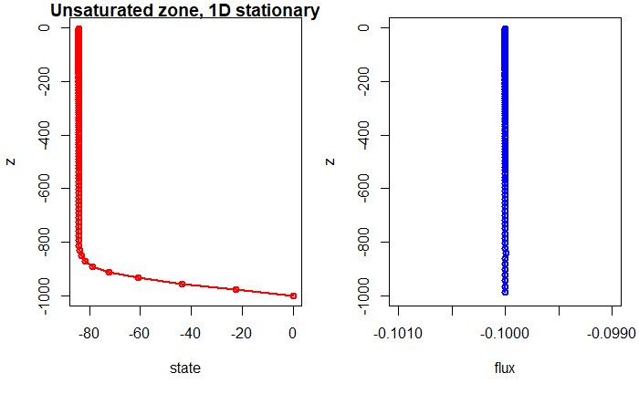

## Additional flow functions

In addition there will be functions for ponding, the lower boundary conditions (simulating the drainage effect) and transpiration of roots (Feddes function). The lower boundary condition is a Cauchy type BC:
$$Q_{drainge}= \frac{H_{drn.level} - H_{bottom}}{C}$$

```
drn.resistance = 1000 #unit is in days
drn.level = -1000 # so 80 cm below surface level
drn.fun = function(psi)
{
#  if((drn.level - (psi + bottom)) < 0) return((drn.level - (psi + bottom))/drn.resistance)
#  else return(0)
  return((drn.level - (psi + bottom))/drn.resistance)
}
```

### Replacing the bottom fixed head boundary condition with the drainage type

```
set.BC.fluxstate(UnsatStat,"left", drn.fun)
summary(UnsatStat)
```

```
one dimensional flow model
name:  Unsaturated zone, 1D stationary
model has no spatial fluxes
model has no point fluxes
left BC is of type state-flux
right BC is of type given flux

numerical model of type FV1D
number of nodes is  291
```

```
drn.psi.equi = approxfun(c(domain[1],domain[2]),c((drn.level - bottom),drn.level))

do.initialize(UnsatStat,drn.psi.equi)
solve.steps(UnsatStat,verboselevel = 1)
```

```
[1] "iteration 1 ; RMSM= 0.00585698601890071 ; MAM= 0.0999126967811539"
[1] "iteration 2 ; RMSM= 0.00584409730686195 ; MAM= 0.0996925095914729"
[1] "iteration 3 ; RMSM= 0.00578735862351465 ; MAM= 0.0987198774157299"
[1] "iteration 4 ; RMSM= 0.00555565467790186 ; MAM= 0.0947049490938961"
[1] "iteration 5 ; RMSM= 0.00492136776247102 ; MAM= 0.0825781942817497"
[1] "iteration 6 ; RMSM= 0.00450593007058228 ; MAM= 0.0754779349389592"
[1] "iteration 7 ; RMSM= 0.00418496110125112 ; MAM= 0.0701419759706102"
[1] "iteration 8 ; RMSM= 0.00388931503489402 ; MAM= 0.0652044048199163"
[1] "iteration 9 ; RMSM= 0.00365933950724155 ; MAM= 0.0610821500864386"
[1] "iteration 10 ; RMSM= 0.00344576696859409 ; MAM= 0.0572813011372447"
[1] "iteration 11 ; RMSM= 0.00341970494026346 ; MAM= 0.0563870150345167"
[1] "iteration 12 ; RMSM= 0.00319280011064072 ; MAM= 0.0526475408861559"
[1] "iteration 13 ; RMSM= 0.00298205991373133 ; MAM= 0.0493645617086123"
[1] "iteration 14 ; RMSM= 0.00278869103676147 ; MAM= 0.046284788697449"
[1] "iteration 15 ; RMSM= 0.00260072194100054 ; MAM= 0.0431471538984293"
```

[output cut: 32 more lines]

```
plot(UnsatStat,fluxplot = T,vertical = T)
```

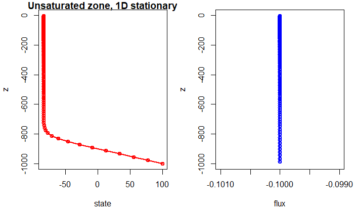

```
##trying the new bottom boundary condition with a view different ppt's
ppt = 0.2
solve.steps(UnsatStat,verboselevel = 1)
```

```
[1] "iteration 1 ; RMSM= 0.005849687839147 ; MAM= 0.0937499999764277"
[1] "iteration 2 ; RMSM= 0.00577394854309319 ; MAM= 0.0922851562277657"
[1] "iteration 3 ; RMSM= 0.0056872422673337 ; MAM= 0.0908432006673718"
[1] "iteration 4 ; RMSM= 0.00561357685142144 ; MAM= 0.0894237756547649"
[1] "iteration 5 ; RMSM= 0.00553863945532336 ; MAM= 0.0880265291607051"
[1] "iteration 6 ; RMSM= 0.00545663705018009 ; MAM= 0.0866511146395749"
[1] "iteration 7 ; RMSM= 0.00539705063229205 ; MAM= 0.0852971909742484"
[1] "iteration 8 ; RMSM= 0.0053419434977888 ; MAM= 0.0839644223657764"
[1] "iteration 9 ; RMSM= 0.00528058745814402 ; MAM= 0.0825921764874239"
[1] "iteration 10 ; RMSM= 0.00518891877334487 ; MAM= 0.0813016737345658"
[1] "iteration 11 ; RMSM= 0.00486456942906952 ; MAM= 0.0762203191121116"
[1] "iteration 12 ; RMSM= 0.0048033818852421 ; MAM= 0.0714565491552544"
[1] "iteration 13 ; RMSM= 0.00474134586124964 ; MAM= 0.070340040574083"
[1] "iteration 14 ; RMSM= 0.00468732459624455 ; MAM= 0.0692409774361488"
[1] "iteration 15 ; RMSM= 0.00468657990390796 ; MAM= 0.0649134163484066"
```

[output cut: 57 more lines]

```
plot(UnsatStat,fluxplot = T,vertical = T)
```

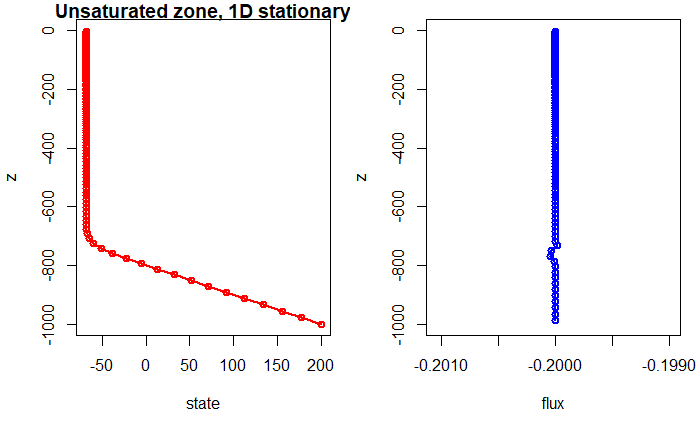

```
#ppt = -0.2
# solve.steps(UnsatStat,verboselevel = 1)
# plot(UnsatStat,fluxplot = T,vertical = T)
# dataframe.balance(UnsatStat)
# dataframe.boundaries(UnsatStat)

###plotting functions showing the water table in the profile,
### the moisture distribution and transpiration through the roots

plot.wtable = function(model)
{
  df = dataframe.states(model)
  plot(df$state, df$x, type = "o",col = "blue",lwd=2.5,
       main = "Psi(z), location water table", xlab = "psi in cm", ylab = "depth profile")
  abline(h = drn.level, col = "brown", lwd= 3, lty = "dashed")
  text(20,drn.level, "drainage level", col = "brown")
  psi.fun = approxfun(df$state,df$x)
  abline(h = psi.fun(0),col = "red", lwd = 2)
  text(20,psi.fun(0),"water table" , col = "red")
  grid()
}

plot.theta = function(model)
{
  df = dataframe.states(model)
  theta.psi = soiltype$theta.fun(df$state)
  plot(theta.psi,df$x, type = "o", col = "green", lwd = 2.5,
       main = "Theta(z), moisture content in profile", xlab = "theta", ylab = "depth profile")
  abline(h = drn.level, col = "brown", lwd= 3, lty = "dashed")
  text((mean(theta.psi)),drn.level, "drainage level", col = "brown")
  grid()
}


plot.wtable(UnsatStat)
```

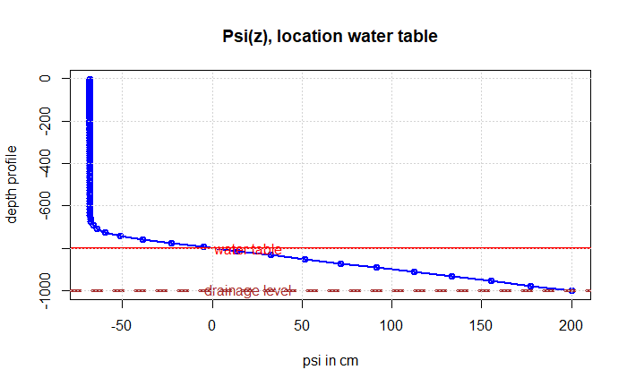

```
plot.theta(UnsatStat)
```

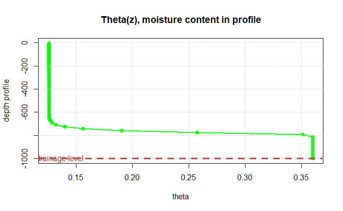

## Adding the vegetation to the model

Evapotranspiration is an important environmental condition for processes near the soil surface, such as the development of vegetation. Evapotranspiration depends on:

- The potential evapotranspiration rate, which is determined by weather conditions;
- The rooting distribution of the vegetation;
- The actual soil moisture contentin the rooting zone.

The total *potential* evapotranspiration rate of the vegetation is determined by weather conditions and will be given.

The rooting distribution may be described by a function `root.distr.fun(z)` which gives the fraction of roots present at each depth (giving 1 when integrated with depth). The rooting depth for each vegetation type can be described in many ways. Here, at this stage we will assume grass with 75% rooting in the first 20 cm and 25% till 110 cm below surface. (Just my guess).

```
root.partition = c(0.0,-20.0,-20.01,-110.0,-110.01)
root.rates.fractions = c(0.75/20,0.75/20,0.25/90,0.25/90,0.0)
root.distr.fun = approxfun(root.partition,root.rates.fractions,rule = 2)
plot(root.partition,root.distr.fun(root.partition), type = "o",
   col = "green", lwd = 2, main = "Root distribution function",
   ylab = "Fraction of the root distribution (-)", xlab = "Rooting depth (cm) rel. to surface level")
grid()
```

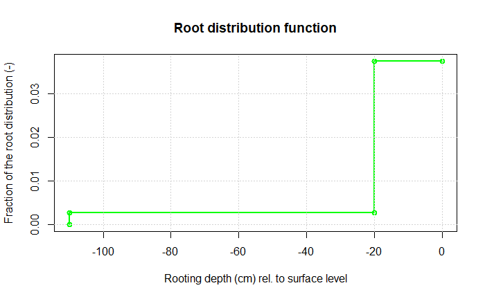

```
###check for the integral
20*0.75/20 + 90*0.25/90
```

```
[1] 1
```

```
z.root = seq(-109.5,-0.5,by = 1)
sum(root.distr.fun(z.root))
```

```
[1] 1
```

The vegetation can only transpire optimally when there is sufficient moisture in the soil which is ‘easily’ available for the vegetation. The effect of soil moisture can be simulated with the so called Feddes (retired Prof. from WUR) function.

The code chunk below illustrates such a Feddes function. This function relates the root water uptake at a certain depth with the pressure (suction) at that depth. When the soil is too wet or too dry, plant transpiration and thus root uptake are reduced below their potential rates, and the Feddes reduction factor is smaller than 1.

```
options(scipen = 999) #avoid scientific notation (with E power) in the plot
Feddes.psiabs = c(0.1,100,1000,16000) #typical psi values to define Feddes function. Note these are absolute psi's due to the plot. NOT in the function
Feddes.red = c(0,1,1,0)
Feddes.fun= approxfun(-Feddes.psiabs,Feddes.red,rule=2)
plot(Feddes.psiabs,Feddes.fun(-Feddes.psiabs),type="l",lwd=3,xlim=rev(range(Feddes.psiabs)),log="x",ylab="Root uptake reduction",xlab="Suction (|psi|)")
abline(v=Feddes.psiabs,col="red")
```

```
text(1,0.9,"Too wet", col="red")
text(300,0.7,"Optimal", col="red")
```

```
text(5000,0.9,"Too dry",col="red")
grid()
```

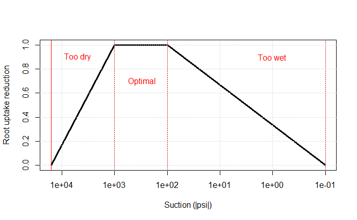

### Adding this spatial flux to the model

The effect of the vegetation, toots extracting water from the soil for transpiration depending on the root distribution, suction ($\psi$) and the potential evapotranpsiration.

Three aspects are considered:

1. Rooting distribution `root.distr.fun`
2. Feddes function `Feddes.fun`
3. Potential evapotranspiration `Epot`

The function to calculate this is : `Eact = root.distr.fun(z)*Feddes.fun(psi)*Epot`

```
Eact = function(z,psi)
{
  return(-root.distr.fun(z) * Feddes.fun(psi) * Epot)
}

add.spatialflux(UnsatStat, rate = Eact, name = "Transpiration")
```

## current model

The current model consists of:

- precipitation applied to the upper boundary as a prescribed flux `ppt`
- potential evapotranspiration `epot` as a flux rate to determine Eact
- actual evapotranspiration `Eact` as a spatial flux (along the roots)
- Cauchy type boundary condition at the lower boundary simulating the effect of a local drainage system

```
plot.roots = function(model)
{
  df = dataframe.externalfluxes(model)
  plot(df$`S{Transpiration}dx`,df$x, type = "o", col = "green", lwd = 2.5,
       main = "Moisture extraction by roots in depth", xlab = "rate (cm/d)", ylab = "depth profile")
  abline(h = drn.level, col = "brown", lwd = 3, lty = "dashed")
  text(mean(df$`S{Transpiration}dx`),drn.level,"drainage level", col = "brown")
  grid()
}

summary(UnsatStat)
```

```
one dimensional flow model
name:  Unsaturated zone, 1D stationary
model has 1 spatial flux, with name
 Transpiration
model has no point fluxes
left BC is of type state-flux
right BC is of type given flux

numerical model of type FV1D
number of nodes is  291
```

```
####testing the model with meteo data
ppt = 0.124
Epot = 0.05#0.2
do.initialize(UnsatStat, drn.psi.equi)
solve.steps(UnsatStat,verboselevel = 1)
```

```
[1] "iteration 1 ; RMSM= 0.00712907936950005 ; MAM= 0.121534697494092"
[1] "iteration 2 ; RMSM= 0.00709940092639787 ; MAM= 0.121028774190837"
[1] "iteration 3 ; RMSM= 0.00704106606626894 ; MAM= 0.120030636385922"
[1] "iteration 4 ; RMSM= 0.00671694913774102 ; MAM= 0.114458867688608"
[1] "iteration 5 ; RMSM= 0.00596471231878682 ; MAM= 0.100212189858662"
[1] "iteration 6 ; RMSM= 0.00454098203809292 ; MAM= 0.0474367705889611"
[1] "iteration 7 ; RMSM= 0.00407351001303925 ; MAM= 0.0429515323183247"
[1] "iteration 8 ; RMSM= 0.00363753525508107 ; MAM= 0.0402732849941438"
[1] "iteration 9 ; RMSM= 0.00328523852623453 ; MAM= 0.0377605784538884"
[1] "iteration 10 ; RMSM= 0.00283483051144702 ; MAM= 0.0349131643746059"
[1] "iteration 11 ; RMSM= 0.00264169920540215 ; MAM= 0.0327455714481138"
[1] "iteration 12 ; RMSM= 0.00246618369816948 ; MAM= 0.0307071314429421"
[1] "iteration 13 ; RMSM= 0.00230248062062387 ; MAM= 0.0287933482833985"
[1] "iteration 14 ; RMSM= 0.00215895999976593 ; MAM= 0.0269972454774358"
[1] "iteration 15 ; RMSM= 0.0020211423349209 ; MAM= 0.025311641187344"
```

[output cut: 23 more lines]

```
plot(UnsatStat,fluxplot = T)
```

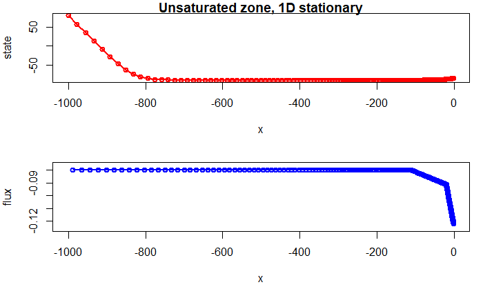

```
plot.wtable(UnsatStat)
```

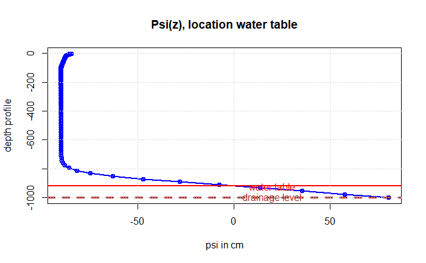

```
plot.theta(UnsatStat)
```

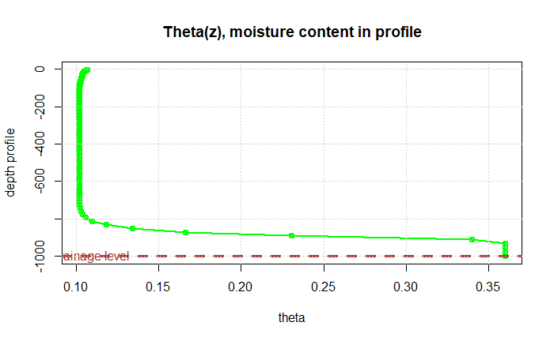

```
plot.roots(UnsatStat)
```

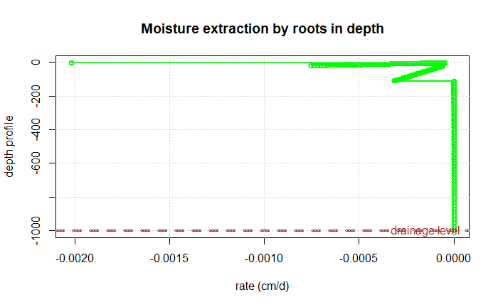

```
bal.asfixedflux = dataframe.balance(UnsatStat)
exter.asfixedflux = dataframe.externalfluxes(UnsatStat)
```

## In case of poding

When the amount of precipitation is larger than the soil can absorb, ponding (nl: plasvorming) will take place To simulate this, an additional Cauchy type boundary condition will be applied to the upper node.

$$q_{ponding} = \frac{\psi_{surface}-0}{C_{top}}$$
It will only be activated when the pressure at the surface (upper node) is larger than 0.0 cm

```
c.top = 5 #days
ponding = function(psi)
{
  if (psi > 0)
  {
    return(-psi/c.top)
  }else{
    return(0)
  }
}
```

## Adjusting the model

We need to replace the `set.BC.fixedflux` upper boundary to an `add.pointflux` function and apply the ponding function to the upper node with `set.BC.fluxstate`.

```
set.BC.fluxstate(model = UnsatStat, where = "right", func = ponding)
add.pointflux(model = UnsatStat, at = 0, value = "ppt", "precipitation")
summary(UnsatStat)
```

```
one dimensional flow model
name:  Unsaturated zone, 1D stationary
model has 1 spatial flux, with name
 Transpiration
model has 1 point flux, with name
 precipitation
left BC is of type state-flux
right BC is of type state-flux

numerical model of type FV1D
number of nodes is  291
```

```
solve.steps(UnsatStat, verboselevel = 1)
```

```
[1] "stopped because of small RMSM= 0.00000000000123831790142469"
$RMSM
[1] 0.000000000001238318

$MAM
[1] 0.00000000001554432
```

```
plot.wtable(UnsatStat)
```

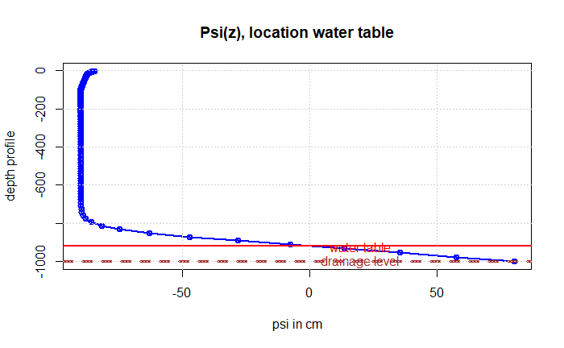

```
plot.theta(UnsatStat)
```

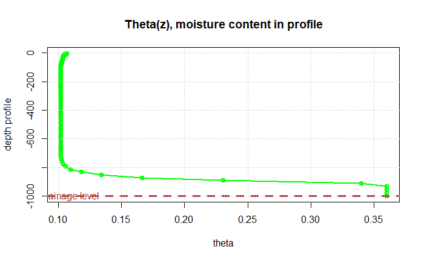

## The transient model

When the dynamics are introduced into the model times series of different aspects could be analyzed. Introducing dynamics means actually that changes in time are considered. This impacts in the first place the amount of water stored in the model: $\frac{\partial \theta}{\partial t}$.

The basic equation to be solved (Richard’s equation) is:
$$\frac{\partial \theta(\psi)}{\partial t} = -k(\psi)\left [\frac{\partial
\psi}{\partial z} + 1 \right]$$

The moisture (storage) change over time (: $\frac{\partial \theta(\psi)}{\partial t}$) is implemented as a `spatial flux` of time and space Since we are calculating $\psi$ as the state of the model, we are going to use the `soiltype$theta.fun(psi)` function to determine the amount of moisture content based on the current pressure head ($\psi$)

This can be implemented numerically as:

$$Q_{storage} = \frac{\theta \left (\psi^{t+\Delta t}\right ) - \theta
\left( \psi^t \right ) }{\Delta t}\Delta z$$
The new/current pressure head is the one which is evaluated at the new time step: $\psi^{t+\Delta t}$ but since we also need to consider the previous pressure head $\psi^t$, we will save these pressure just before we start with a new time step and call this `psi.old`.
When more water is stored in the model, it means that less is available for flow. This means that a minus sign should be introduced. This could easily be accomplished by switching both pressure heads in the aforementioned equation.

```
storage = function(z,state)
{
  storage = (soiltype$theta.fun(psi.old(z)) - soiltype$theta.fun(state))/delta.t
}
```

Be aware the `storage` function will be multiplied with the nodal distance internally to come to the unit of L/T (cm/d).

### Setting up the transient model

A copy of the stationary model is used to quickly set up the transient model

```
UnsatTrans = copy.model(UnsatStat)
add.spatialflux(UnsatTrans, rate = storage, name = "Storage")
do.initialize(UnsatTrans, init = drn.psi.equi)
psi.old = state.fun(UnsatTrans) #setting the strating state of the transient simulation to determine the first storage change
```

Creating a time loop for the calculations

A function to write the required out put in different data.frames for analysis and inspection later on.

```
save.data = function(model = modelname)
{
  df.state = dataframe.states(model)
  state.tmp <<- rbind(state.tmp,df.state$state) #adding the states (psi) to this data.frame
  df.extern = dataframe.externalfluxes(model)
  transp.tmp <<- rbind(transp.tmp,df.extern$`S{Transpiration}dx`) #for transpiration(roots) data
  moist.tmp <<- rbind(moist.tmp,df.extern$`S{Storage}dx`)
  #balance terms transp:[2,3],flow2sto:[3,2],sto2flow[3,3]
  df.balance = dataframe.balance(model)
  #the drainage/upward seepage at the bottom will be written in balance.dat
  df.bound = dataframe.boundaries(model)
  balance.tmp <<- rbind(balance.tmp,c(precip[current.time],evapot[current.time],
                                      df.balance[2,3],df.balance[3,2],
                                      df.balance[3,3],df.bound[1,4],df.bound[2,4]))
}
```

Reading some meteo data from KNMI, precipitation and potential evapotranspiration In the file it reads: RH = Etmaalsom van de neerslag (in 0.1 mm) (-1 voor <0.05 mm) / Daily precipitation amount (in 0.1 mm) (-1 for <0.05 mm) EV24 = Referentiegewasverdamping (Makkink) (in 0.1 mm) / Potential evapotranspiration (Makkink) (in 0.1 mm)

```
meteo = read.table(file = "ppt_epot2020.txt", header = TRUE)
names(meteo) = c("date","ppt","epot")
#adjusting the unit to cm/day
precip = meteo$ppt/100
evapot = meteo$epot/100
#correcting for the -1 symbol and setting these values to 0
precip[which(precip < 0)] = 0
evapot[which(evapot < 0)] = 0
```

### Base run

```
begin.time  = 1
current.time = begin.time
end.time = length(meteo$date)
delta.t = 1 #day, i.e. the time stepping


####containers to save intermediate results
state.tmp = c()
transp.tmp = c()
moist.tmp = c()
balance.tmp = c()

##set the initial state to equilibrium
do.initialize(UnsatTrans, init = drn.psi.equi)
start.run.time = Sys.time()
while(current.time <= end.time)
{
  ppt = precip[as.integer(current.time)]
  Epot = evapot[as.integer(current.time)]
  psi.old = state.fun(UnsatTrans)
  solve.steps(UnsatTrans)#,verboselevel = 1)
  plot.wtable(UnsatTrans)
  cat(paste("day nr.:",current.time, "\n"))
  save.data(UnsatTrans)
  current.time = current.time + delta.t
  ####plotting some stuff
  # old.par = par(no.readonly=TRUE) #to save current plot settings and stuff
  # layout = matrix(c(2,2),ncol = 2)#, byrow = TRUE)
  # plot.roots(UnsatTrans)
  # plot.theta(UnsatTrans)
  # plot.wtable(UnsatTrans)
  # par = old.par
  #####saving the results
}
```

```
day nr.: 1
```

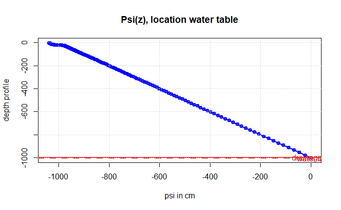

```
day nr.: 2
```

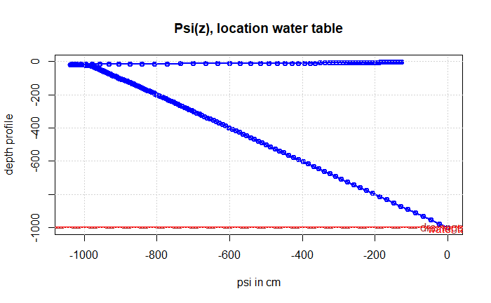

```
day nr.: 3
```

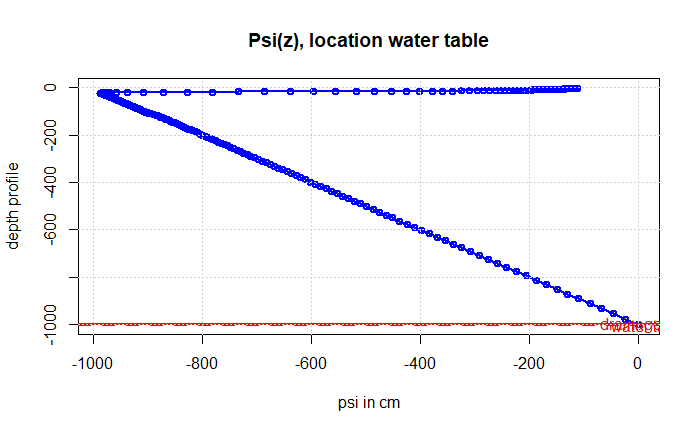

```
day nr.: 4
```

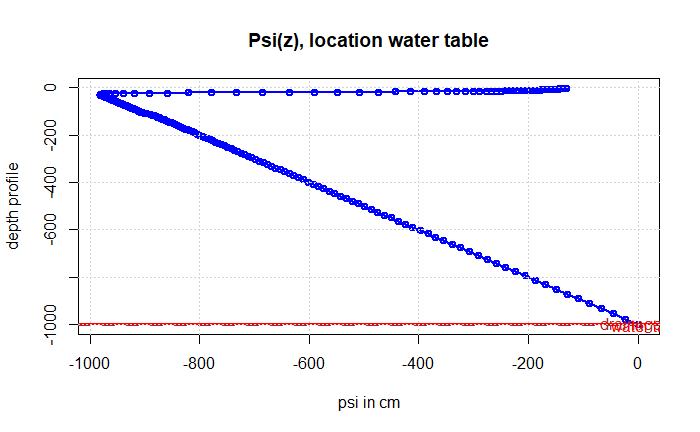

```
day nr.: 5
```

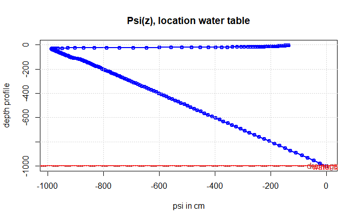

```
day nr.: 6
```

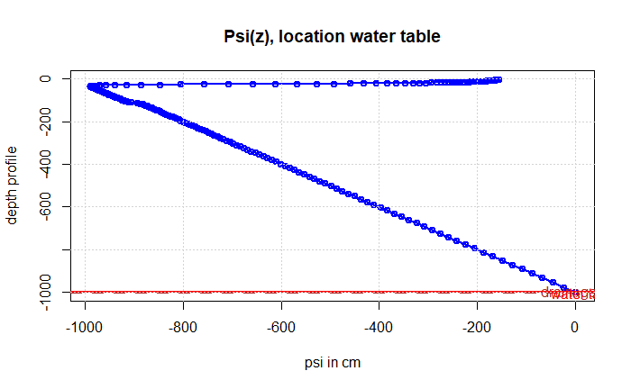

```
day nr.: 7
```

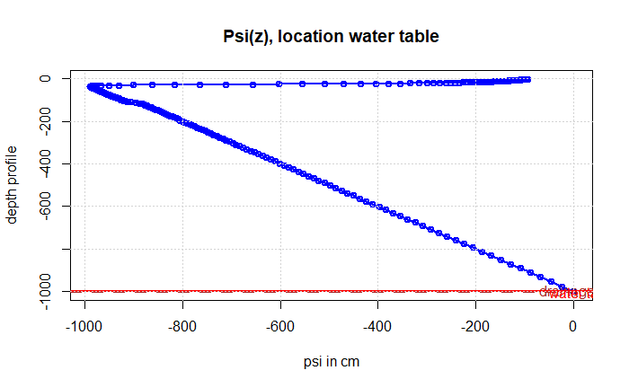

```
day nr.: 8
```

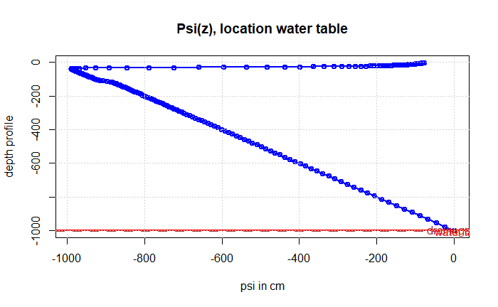

```
day nr.: 9
```

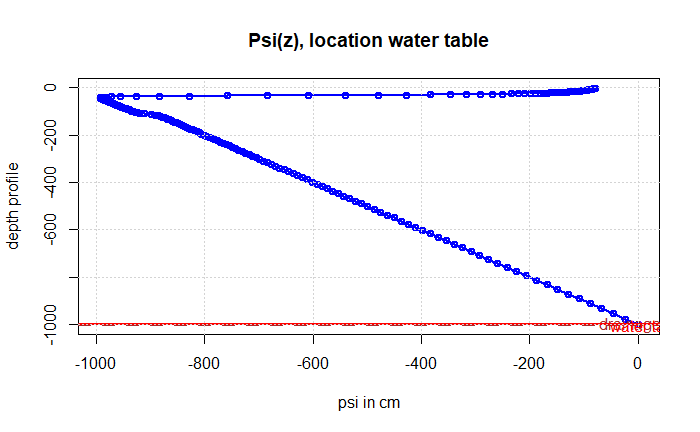

```
day nr.: 10
```

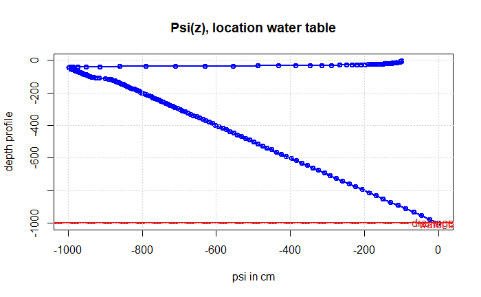

```
day nr.: 11
```

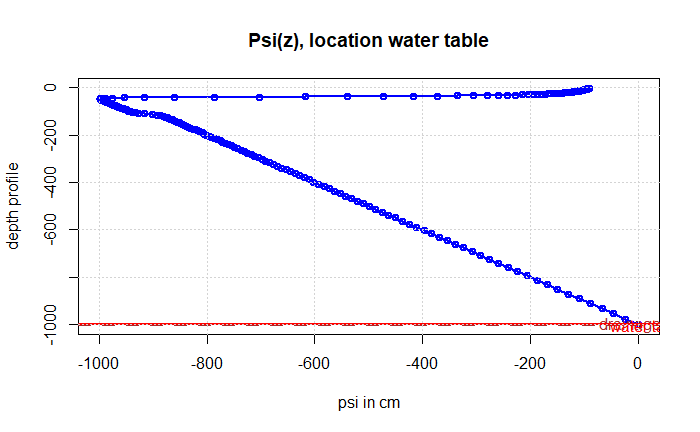